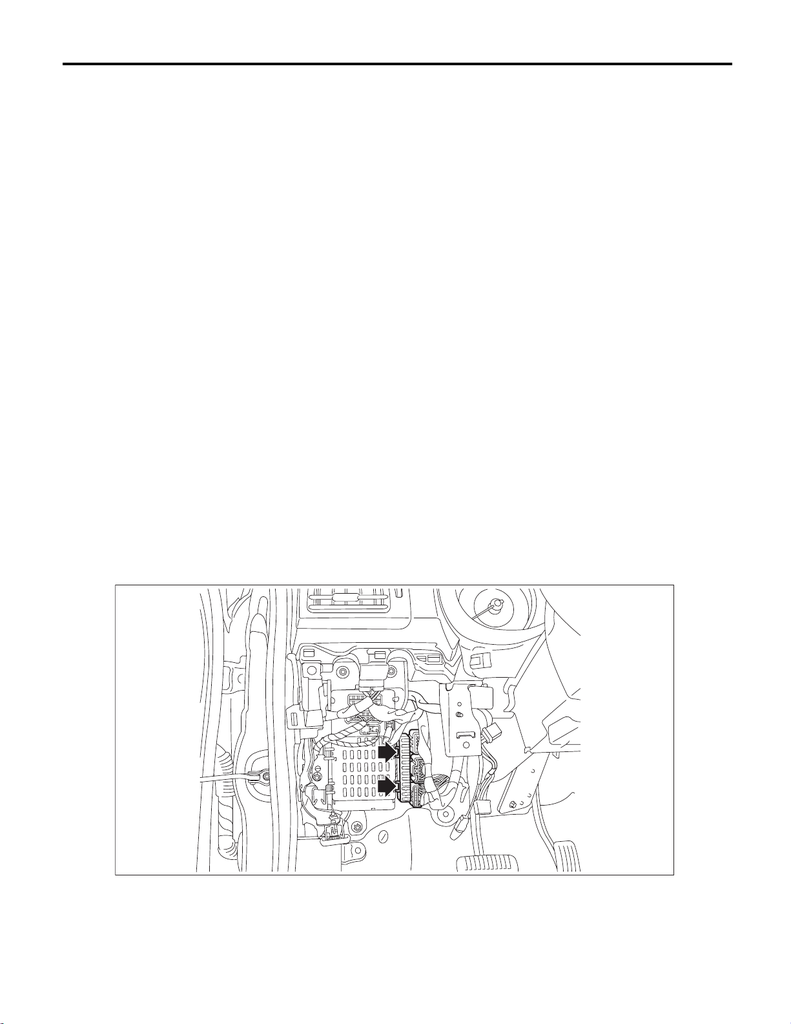

SL-78

Body Integrated Unit

SECURITY AND LOCKS

24.Body Integrated Unit

A: NOTE

1. WHEN REPLACING THE BODY INTEGRATED UNIT

TION, Registration Body Integrated Unit.>

2) Prepare all immobilizer keys already registered. (Model without keyless access)

NOTE:

If some of the registered immobilizer keys are missing, the following parts must be replaced.

• Except for C0 model: combination meter

• For C0 model: security control module

2. AFTER REPLACING THE BODY INTEGRATED UNIT

1) Register the immobilizer. (Model without keyless access)

NOTE:

For detailed operation procedure, refer to the “REGISTRATION MANUAL FOR IMMOBILIZER”.

2) Set the current settings as recorded.

B: REMOVAL

CAUTION:

TEM”. <Ref. to AB-9, CAUTION, General Description.>

NT-5, BATTERY, NOTE, Note.>

NOTE:

For models other than STI model, disconnect the ground terminal from battery sensor.

Lower Cover.>

3) Remove the knee airbag module. <Ref. to AB-35, REMOVAL, Knee Airbag Module.>

4) Release the lock and remove the fuse holder.

SL-01530

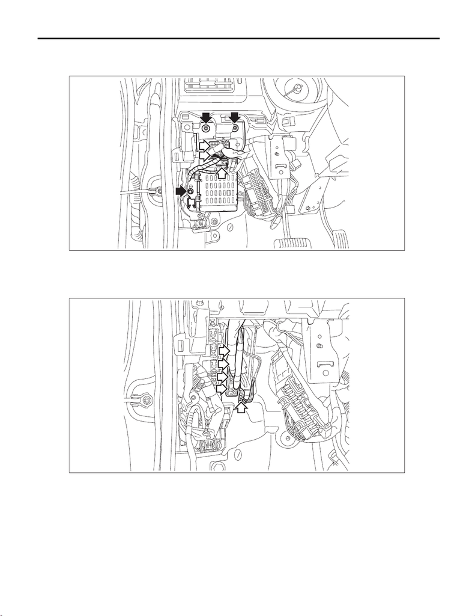

SL-79

Body Integrated Unit

SECURITY AND LOCKS

5) Remove the relay & fuse box.

(1) Disconnect the connector.

(2) Remove the bolts and nuts, and remove the relay & fuse box.

6) Remove the body integrated unit.

CAUTION:

Be careful to keep water and other foreign materials away from body integrated unit.

(1) Disconnect the connector.

SL-01531

SL-01532

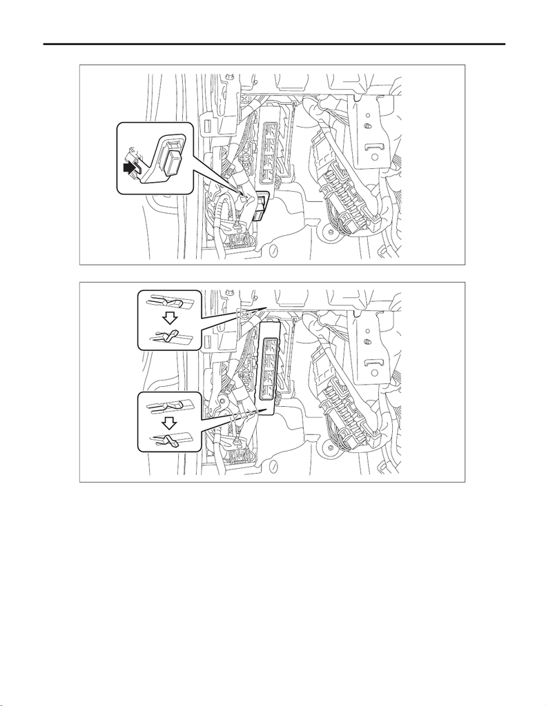

SL-80

Body Integrated Unit

SECURITY AND LOCKS

(2) Release the lock and remove the data link connector bracket.

(3) Release the claws, and pull out the body integrated unit.

SL-01552

SL-01533

[figure not shown]

SL-81

Body Integrated Unit

SECURITY AND LOCKS

C: INSTALLATION

CAUTION:

TEM”. <Ref. to AB-9, CAUTION, General Description.>

NOTE:

BC(diag)-15, LIST, Read Current Data.>

1) Install the body integrated unit.

2) Install the relay & fuse box and fuse holder.

Tightening torque:

Relay & fuse box: 7.5 N·m (0.8 kgf-m, 5.5 ft-lb)

3) Install the cover assembly - instrument panel LWR driver and the knee airbag module.

4) Connect the battery ground terminal. <Ref. to NT-5, BATTERY, NOTE, Note.>

NOTE:

For models other than STI model, connect the ground terminal to battery sensor.